title: “ex11: lasso, ridge and elastic net” output: html_document —

## a) preprocessing

the same as in ex9:

```r
data(ozone, package="gss")
d.ozone <- subset(transform(ozone, logupo3= log(upo3)), select = -upo3)
d.ozone.e <- d.ozone[-which.max(d.ozone[,"wdsp"]),] # remove outlier
```

## b) generate formula and according design matrix for penalized regression

```r
require(sfsmisc)
ff <- wrapFormula(logupo3 ~ ., data=d.ozone.e, wrapString="poly(*,degree=3)")
ff <- update(ff, logupo3 ~ .^3)
mm <- model.matrix(ff, data=d.ozone.e)
```

## c) ridge and lasso

```r
# install.packages("glmnet")
library(glmnet)
ridge <- glmnet(mm, d.ozone.e$logupo3, alpha=0)
summary(ridge)
```

```
##           Length Class     Mode
## a0           100 -none-    numeric
## beta      262000 dgCMatrix S4
## df           100 -none-    numeric
## dim            2 -none-    numeric
## lambda       100 -none-    numeric
## dev.ratio    100 -none-    numeric
## nulldev        1 -none-    numeric
## npasses        1 -none-    numeric
## jerr           1 -none-    numeric
## offset         1 -none-    logical
## call           4 -none-    call
## nobs           1 -none-    numeric
```

```r
lasso <- glmnet(mm, d.ozone.e$logupo3, alpha=1)
summary(lasso)
```

```
##           Length Class     Mode
## a0           100 -none-    numeric
## beta      262000 dgCMatrix S4
## df           100 -none-    numeric
## dim            2 -none-    numeric
## lambda       100 -none-    numeric
## dev.ratio    100 -none-    numeric
## nulldev        1 -none-    numeric
## npasses        1 -none-    numeric
## jerr           1 -none-    numeric
## offset         1 -none-    logical
## call           4 -none-    call
## nobs           1 -none-    numeric
```

Plot the coeffs as a function of lambda.

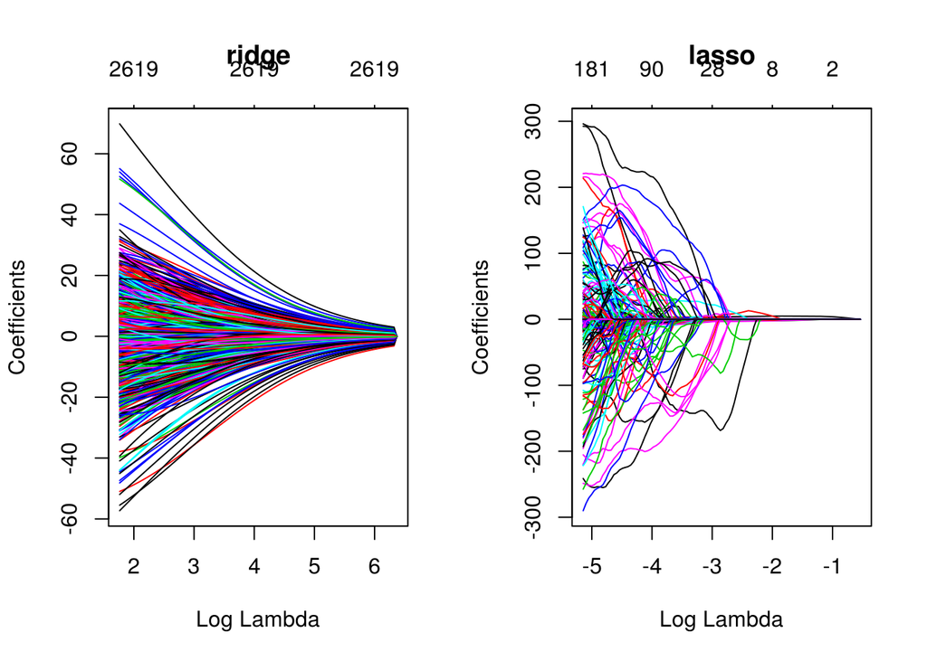

```r
par(mfrow=c(1,2))
plot(ridge, xvar="lambda", main="ridge")
plot(lasso, xvar="lambda", main="lasso")
```

Remark: >The plot shows the difference properties of the 2: in ridge as lambda goes up, the coeffs do not suddenly become 0; in lasso, as lambda goes up, more and more coeff vanish.

## d) select best lambda: 10-fold CV, and 1-s.e. rule by MSE-log(lambda) plot

Look at the documentation for cv.glmnet: the resulting object has a `lambda.1se` – largest value of lambda such that error is within 1 standard error of the minimum.

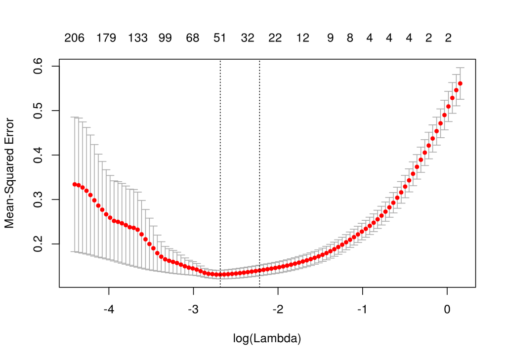

```r
set.seed(1)
par(mfrow=c(1,1))
cv.eln <- cv.glmnet(mm, d.ozone.e$logupo3, alpha=0.5, nfolds=10)
plot(cv.eln)
```

```r
print(cv.eln$lambda.1se)
```

```
## [1] 0.1088267
```

==> selected lambda=0.10883

## e) compare with gam

recover the CV score for best lambda:

```r
cv.eln$cvm[ which( cv.eln$lambda==cv.eln$lambda.1se ) ]
```

```
## [1] 0.1404099
```

```r
require(mgcv)
gamForm <- wrapFormula(logupo3~., data=d.ozone.e)
g1 <- gam(gamForm, data=d.ozone.e)
summary(g1)
```

```
##
## Family: gaussian
## Link function: identity
##
## Formula:
## logupo3 ~ s(vdht) + s(wdsp) + s(hmdt) + s(sbtp) + s(ibht) + s(dgpg) +
##     s(ibtp) + s(vsty) + s(day)
##
## Parametric coefficients:
##             Estimate Std. Error t value Pr(>|t|)
## (Intercept)   2.2148     0.0172   128.8   <2e-16 ***
## ---
## Signif. codes:  0 '***' 0.001 '**' 0.01 '*' 0.05 '.' 0.1 ' ' 1
##
## Approximate significance of smooth terms:
##           edf Ref.df      F  p-value
## s(vdht) 1.000  1.000 10.878 0.001087 **
## s(wdsp) 1.046  1.090  8.856 0.003093 **
## s(hmdt) 2.372  2.983  2.454 0.057053 .
## s(sbtp) 3.855  4.803  4.155 0.001426 **
## s(ibht) 2.785  3.407  5.386 0.000969 ***
## s(dgpg) 3.267  4.153 14.380 4.95e-11 ***
## s(ibtp) 1.000  1.000  0.441 0.507315
## s(vsty) 5.513  6.671  6.088 2.21e-06 ***
## s(day)  4.616  5.741 25.029  < 2e-16 ***
## ---
## Signif. codes:  0 '***' 0.001 '**' 0.01 '*' 0.05 '.' 0.1 ' ' 1
##
## R-sq.(adj) =  0.826   Deviance explained =   84%
## GCV = 0.10579  Scale est. = 0.097287  n = 329
```

==> gcv(gam) is 0.106, the cv score of chosen eln is 0.1404. Both scores are quite small, but they are not directly comparable as a different type of CV was used in each of them.

Therefore, one would have to compute the same type of CV for both methods and compare their scores. ==> write code to calculate 10-cv for gam:

```r
n <- nrow(d.ozone.e)
cv.MSE <- numeric(10)
for(i in 1:10){
  ind.test <- as.integer(n*(i-1)/10+1):as.integer(n*i/10)
  fit <- gam(gamForm, data=d.ozone.e[-ind.test,])
  pred <- predict.gam(fit, newdata=d.ozone.e[ind.test,])
  cv.MSE[i] <- mean( (d.ozone.e$logupo3[ind.test]-pred)^2 )
}
print(mean(cv.MSE))
```

```
## [1] 0.1174278
```

==> thus maybe gam is better.